# Species Richness, Abundance, and Composition of Ground-Dwelling Ants in Northern California Grasslands: Role of Plants, Soil, and Grazing | Environmental Entomology | Oxford Academic

### Data Analysis.

To meet parametric assumptions, we log transformed all continuous variables and arcsine transformed all percentage data. Wherever means are reported, they are followed by their standard deviations. We analyzed the data via independent-sample *t*-tests and regressions (both linear and logistic) ([Sokal and Rohlf 1995](https://academic.oup.com/ee/article/34/1/96/478963?login=true), [Neter et al. 1996](https://academic.oup.com/ee/article/34/1/96/478963?login=true)). To detect any interaction effects between the two independent variables, namely, soil type (serpentine and nonserpentine) and grazed versus ungrazed plots, we performed a two-way analysis of variance (ANOVA) ([Sokal and Rohlf 1995](https://academic.oup.com/ee/article/34/1/96/478963?login=true)) on all dependent variables. Only significant results are reported for this series of tests.

Grazing was used as an independent variable in an analysis of covariance (ANCOVA) of ant species richness and abundance with plant and soil attributes as covariates ([Sokal and Rohlf 1995](https://academic.oup.com/ee/article/34/1/96/478963?login=true)). Stepwise regressions, *t*-tests, ANOVAs, and ANCOVAs were carried out using the statistical computer package SPSS, ver-sion8.0 for Windows (O’[Connor 2004](https://academic.oup.com/ee/article/34/1/96/478963?login=true)). Principal component analysis (PCA) was run on all soil response variables by using PC-ORD, version 4.0 ([Gilliam and Saunders 2003](https://academic.oup.com/ee/article/34/1/96/478963?login=true)). A correlation matrix was used for this analysis. Principal component scores were then used as additional response variables (after [Culver and Beattie 1983](https://academic.oup.com/ee/article/34/1/96/478963?login=true)). Positive and negative symbols preceding a number and/or a variable indicate the direction of the association throughout the text, unless otherwise noted. We applied the Bonferroni correction to each *t*-test by multiplying its corresponding *P* value by the number of tests executed for that particular variable ([Sokal and Rohlf 1995](https://academic.oup.com/ee/article/34/1/96/478963?login=true)).

To determine whether soil attributes and plant composition correlated with composition of the ant community, we compared their dissimilarity matrices. First, we calculated the Sorensen–Czekanowski metric ([Fortin and Gurevitch 1993](https://academic.oup.com/ee/article/34/1/96/478963?login=true), [Legendre and Legendre 1998](https://academic.oup.com/ee/article/34/1/96/478963?login=true)) to measure the dissimilarity in species composition (presence or absence) between sites for both plants and ants. We then used the Gower metric ([Gower 1971](https://academic.oup.com/ee/article/34/1/96/478963?login=true)) to measure the dissimilarity in soil attributes between sites.

To test for an association between plant and ant communities, we computed the partial Mantel statistic r<sub>AB C</sub> (the correlation between matrix A and B, given C) ([Smouse et al. 1986](https://academic.oup.com/ee/article/34/1/96/478963?login=true)). We used this statistic to describe the effect of plant composition on ant community when the effect of soil attributes was removed. A positive value for r<sub>AB.C</sub> indicates an effect of the plant community on the ant community, whereas rAB.C equal to or less than zero indicates no effect. We used partial Mantel tests for positive r<sub>AB.C</sub> by the first method of [Smouse et al. (1986)](https://academic.oup.com/ee/article/34/1/96/478963?login=true), by using the algorithm given in [Legendre and Legendre (1998)](https://academic.oup.com/ee/article/34/1/96/478963?login=true) (p. 558). For each test, we used 9999 permutations and calculated one-tailed permutation probabilities. Finally, we repeated the partial Mantel test to look at the effect of soil attributes on ant community composition when the effect of the plant community composition was removed.

## Results

### Principal Component Analyses of Soil Data.

Three PCAs were run on the soil data: one on all data combined (abbreviated as PC-all hereafter), one on the serpentine portion of the data (abbreviated as PC-serp hereafter), and one on the nonserpentine data (abbreviated as PC-nonserp hereafter) ([Table 2](https://academic.oup.com/ee/article/34/1/96/478963?login=true)). The first three eigenvalues explained 47.6% of the cumulative variance for PC-all, 47.7% for PC-serp, and 48.3% for PC-nonserp. The PC coordinate scores from these three eigenvalues were then used as independent variables in the regressions and *t*-tests below. Due to some colinearity between PC-all and PC-serp and PC-all and PC-nonserp, PC-all scores were used for analyses on all the data combined, PC-serp scores were confined to analyses on serpentine data, and PC-nonserp, to nonserpentine data. [Table 2](https://academic.oup.com/ee/article/34/1/96/478963?login=true) lists the soil factors associated with principal component. As expected, all three PC axes for the combined data were significantly associated with the serpentine/nonserpentine classification in [Harrison et al. (2003)](https://academic.oup.com/ee/article/34/1/96/478963?login=true): PC1-all, *F* = 120.6; df = 1, 76; *P* < 0.0001; PC2-all, *F* = 6.39; df = 1, 76; *P* = 0.014; PC3-all, *F* = 4.56; df = 1, 76; *P* = 0.036. There were no significant main effects for these three axes on the other independent variable (grazing), nor any interaction effects.

Table 2.

PCA for combined (PC-all), serpentine (PC-serp), and nonserpentine (PC-nonserp) soil data sets

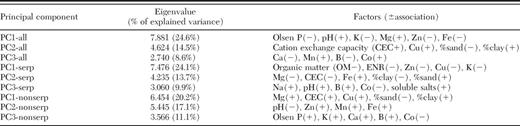

The first three eigenvalues explained approximately one-half of the variance for each data set. If a variable's eigenvector was >±0.25, it was included in the factor column. Symbols from the periodic table of elements were used for soil chemistry variables.

[figure not shown]